# ODT

# Example Using Gene Expression Data

In this example, we will use a matrix called `gene_small`, which contains gene expression information, along with a drug response matrix named `drug_small` for selected patients.

First, we will train the decision tree using the selected data with the `trainTree` function. The required inputs for this function are:

- **PatientData**: The numeric matrix containing gene expression information, where rows correspond to patients/samples and columns correspond to genes/features.
- **PatientSensitivity**: The matrix that provides drug response information, where rows correspond to patients/samples and columns correspond to drugs.
- **minbucket**: A fixed parameter that specifies the minimum number of patients required in a branch of the tree to allow a split.

```r
 ODT_EXP <- trainTree(PatientData = gene_small, PatientSensitivity = drug_small, minbucket = 1)
```

The output of the `trainTree` function will be a decision tree that reflects the splits made by the *ODT* algorithm based on the provided genomic and sensitivity data, along with the treatments assigned at each split. To visualize the optimized tree, we will use the `niceTree` function. This function displays the biomarker selected at each node and the treatment assigned to each branch.

The necessary inputs for the `niceTree` function are:

- **tree**: The trained decision tree obtained from the `trainTree` function.
- **folder**: The directory where the output image will be saved.

Additionally, users can customize several fixed parameters related to the plot’s appearance:

- **colors**
- **fontname**
- **fontstyle**
- **shape**
- **output_format**

For more information regarding plot customization options, please refer to the `niceTree` function documentation.

```r
niceTree(tree = ODT_EXP, folder = NULL)
```

To determine the treatment selected for each specific patient, we will use the `predictTree` function. This function identifies the treatment assigned by the algorithm based on the trained decision tree and the provided patient data. The required inputs for this function are:

- **tree**: The trained decision tree obtained from the `trainTree` function.
- **PatientData**: The numeric matrix containing gene expression information, where rows correspond to patients/samples and columns correspond to genes/features.
- **PatientSensitivityTrain**: A matrix containing the drug response values of the **training dataset**. In this matrix, rows correspond to patients, and columns correspond to drugs. It is only for extracting treatment names and is not used in the prediction process itself.

The following code snippet demonstrates how to use the `predictTree` function:

```r
# Load the necessary library and datasets
library(ODT)

# Load the gene expression and drug response data
data("expression_w34")
data("drug_response_w34")

# Select a subset of the gene expression and drug response data
gene_small <- expression_w34[1:3, 1:3]
drug_small <- drug_response_w34[1:3, 1:3]

# Train the decision tree using the selected patient data
ODT_EXP <- trainTree(PatientData = gene_small, PatientSensitivity = drug_small, minbucket = 1)

# Visualize the trained decision tree
niceTree(ODT_EXP)
```

```
## $Tree
## [1] root
## |   [2] TSPAN6 <= -0.86591: Crizotinib (PF-2341066)
## |   [3] TSPAN6 > -0.86591: Axitinib (AG-013736)
##
## $Plot
```

```r
# Predict the optimal treatment for each patient
ODT_EXPpred <- predictTree(tree = ODT_EXP, PatientSensitivityTrain = drug_small, PatientData = gene_small)

# Retrieve and display the names of the selected treatments
selected_treatments <- colnames(drug_small)[ODT_EXPpred]
selected_treatments
```

```
## [1] "Crizotinib (PF-2341066)" "Axitinib (AG-013736)"
## [3] "Axitinib (AG-013736)"
```

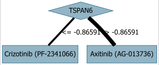

**Figure 3. Trained Decision Tree Output from the *niceTree* Function: This figure illustrates the decision tree generated by the ODT algorithm, showcasing the splits based on expression data and the corresponding treatments assigned at each node.**

# Example: Assigning Optimal Treatment to New Patients (Mutational Data)

In this example, we will use a binary matrix containing mutation information along with a drug response matrix from existing patients. We will train a model to later predict the best treatment for a new patient whose sensitivity response to different treatments is unknown.

```r
# Load the necessary library and datasets
library(ODT)
data("mutations_w34")
data("mutations_w12")
data("drug_response_w12")
data("drug_response_w34")

# Define a binary matrix for new patients (using the first patient as an example)
mut_newpatients<-mutations_w34[1, ,drop=FALSE]

# Train the decision tree model using known patient data
ODT_MUT<-trainTree(PatientData = mutations_w12, PatientSensitivity=drug_response_w12, minbucket =10)

# Visualize the trained decision tree
niceTree(ODT_MUT,folder=NULL)
```

```
## $Tree
## [1] root
## |   [2] NRAS <= 1
## |   |   [3] KRAS <= 1
## |   |   |   [4] BCOR <= 1
## |   |   |   |   [5] PTPN11 <= 1
## |   |   |   |   |   [6] TP53 <= 1
## |   |   |   |   |   |   [7] CBFB-MYH11 <= 1
## |   |   |   |   |   |   |   [8] CEBPA <= 1: Quizartinib (AC220)
## |   |   |   |   |   |   |   [9] CEBPA > 1: AZD1480
## |   |   |   |   |   |   [10] CBFB-MYH11 > 1: JNJ-28312141
## |   |   |   |   |   [11] TP53 > 1: XAV-939
## |   |   |   |   [12] PTPN11 > 1: Panobinostat
## |   |   |   [13] BCOR > 1: RAF265 (CHIR-265)
## |   |   [14] KRAS > 1: Selumetinib (AZD6244)
## |   [15] NRAS > 1: Trametinib (GSK1120212)
##
## $Plot
```

```r
# Predict the optimal treatment for the new patient
ODT_MUTpred<-predictTree(tree=ODT_MUT, PatientSensitivityTrain=drug_response_w12, PatientData=mut_newpatients)

# Retrieve and display the name of the selected treatment
selected_treatment <- colnames(drug_response_w12)[ODT_MUTpred]
selected_treatment
```

```
## [1] "Quizartinib (AC220)"
```

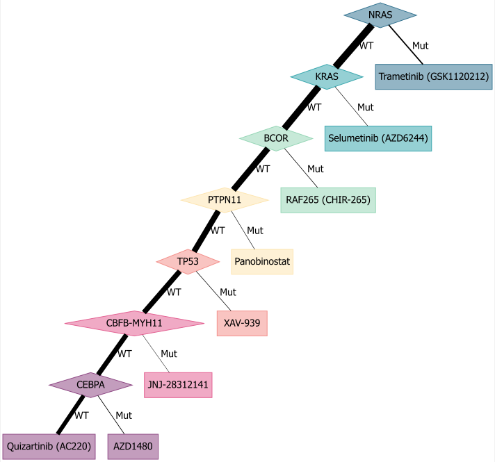

**Figure 4. Trained Decision Tree for New Patients Using Mutational Data: This figure illustrates the output of the *niceTree* function, showcasing the decision tree trained on existing patient data. It highlights the splits based on mutation information and the treatment recommendations for new patients.**

# Example: Assigning Optimal Treatment to New Patients (Gene Expression Data)

In this example, we will use a matrix containing gene expression information along with a drug response matrix from existing patients. We will train a model to predict the best treatment for a new patient whose sensitivity response to different treatments is unknown.

```r
# Load the necessary library and datasets
library(ODT)

# Load gene expression and drug response data
data("expression_w34")
data("expression_w12")
data("drug_response_w12")
data("drug_response_w34")

# Define a matrix for new patients (using the first patient as an example)
exp_newpatients <- expression_w34[1, , drop = FALSE]
# Train the decision tree model using known patient data
ODT_EXP <- trainTree(PatientData = expression_w12, PatientSensitivity = drug_response_w12, minbucket = 10)

# Visualize the trained decision tree
niceTree(ODT_EXP, folder = NULL)
```

```
## $Tree
## [1] root
## |   [2] VCAN <= 6.53
## |   |   [3] VAMP3 <= 7.55
## |   |   |   [4] LUC7L <= 5.44: ABT-737
## |   |   |   [5] LUC7L > 5.44: Venetoclax
## |   |   [6] VAMP3 > 7.55: CHIR-99021
## |   [7] VCAN > 6.53
## |   |   [8] TEAD3 <= -1.41: Trametinib (GSK1120212)
## |   |   [9] TEAD3 > -1.41
## |   |   |   [10] LRP6 <= -1.74: JNJ-28312141
## |   |   |   [11] LRP6 > -1.74: Panobinostat
##
## $Plot
```

```r
# Predict the optimal treatment for the new patient
ODT_EXPpred <- predictTree(tree = ODT_EXP, PatientSensitivityTrain = drug_response_w12, PatientData = exp_newpatients)

# Retrieve and display the name of the selected treatment
selected_treatment <- colnames(drug_response_w12)[ODT_EXPpred]
selected_treatment
```

```
## [1] "Panobinostat"
```

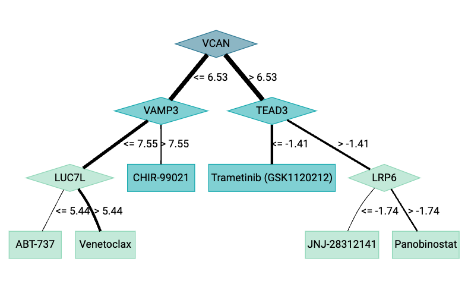

**Figure 5. Trained Decision Tree for New Patients Using Genomic Expression Data: This figure illustrates the output of the *niceTree* function, showcasing the decision tree trained on existing patient data. It highlights the splits based on gene expression information and the treatment recommendations for new patients.**

# References

More information can be found at:

1. Gimeno, M., Sada del Real, K., & Rubio, A. (2023). Precision oncology: a review to assess interpretability in several explainable methods. *Briefings in Bioinformatics*, 24(4), bbad200. https://doi.org/10.1093/bib/bbad200